# Minería de datos de Twitter para analizar eventos políticos y movimientos sociales

Daniela de los Santos

6 de julio de 2021

# Para empezar, necesitaremos hacernos amigas de la API de Twitter.

## ¿Qué permite hacer la API de Twitter?

- Poder acceder masivamente a información sobre:
- Tweets
- Usuarios
- DMs
- Tendencias
- Listas
- Lugares
- Multimedia

## **Limitaciones**

- Se puede acceder gratuitamente a tuits que tienen hasta una semana de antiguedad.
- Para acceder a tweets de “archivo”, se pueden utilizar bùsquedas históricas, pero habrá que activar una opción especial en nuestro dashboard de desarrolladoras, y pagar.

# Pasos iniciales para scrapear datos de Twitter

## El primer paso es contar con una cuenta de “desarrollador” (developer) en Twitter.

- (Esto no es tan difícil como parece)

## Antes que nada, obviamente, hay que tener una cuenta de Twitter

[figure not shown]

Pueden crear una cuenta en [Twitter](https://twitter.com) o loguearse con una cuenta que ya tengan.

## Luego hay que aplicar para una cuenta de Developer.

[figure not shown]

En este link: https://developer.twitter.com/en, dar click en Apply para empezar el proceso.

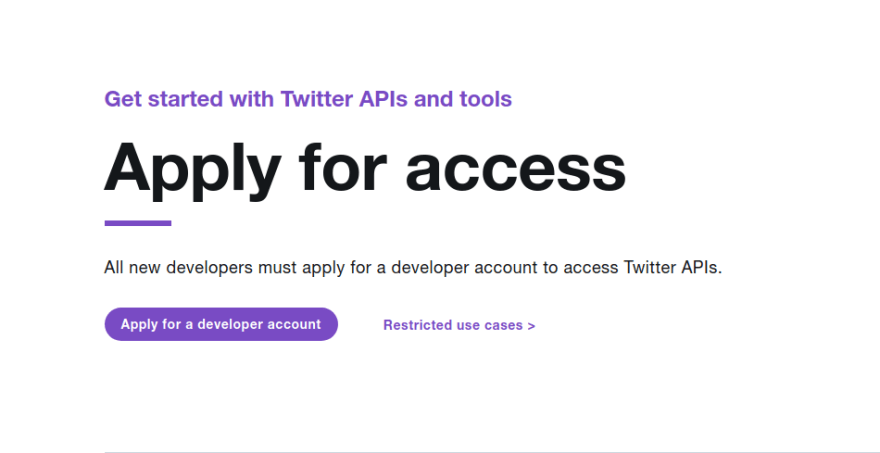

En la página siguiente, clic en “Apply for a Developer account”

## Twitter les pedirá que especifiquen el propósito para el que quieren una cuenta desarrollador.

[figure not shown]

Yo suelo marcar “Academic Research”. Los propósitos “Hobbyist”, “Academic” y “Other” son los de uso individual.

## De hecho, lo próximo que tienen que marcar es si la cuenta es para uso individual o para equipos (empresas, organizaciones, etc.)

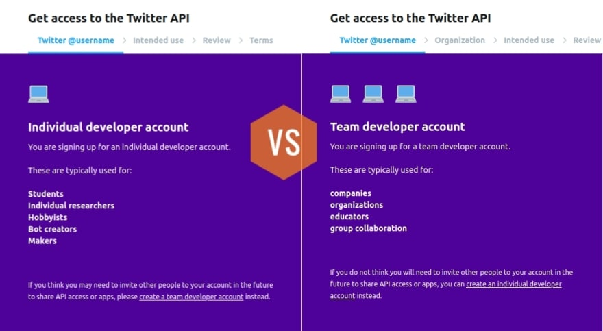

Si eligen uso profesional y cuenta para equipos, tendrán que especificar información sobre su empresa u organización.

## Especificación del ‘intended use’

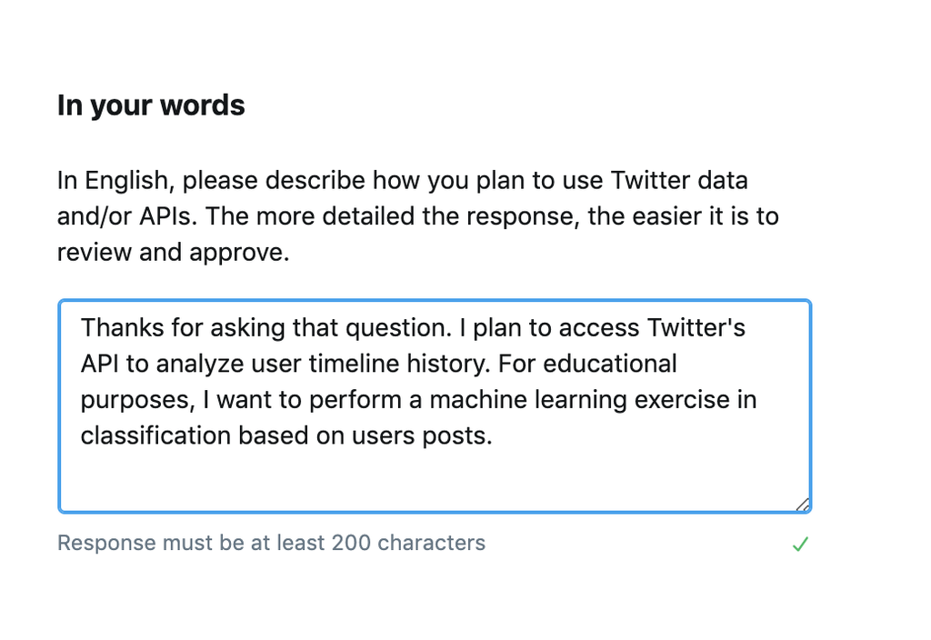

Tendrán que escribir brevemente en inglés qué es lo que quieren hacer. En este punto, hay que ser específico, porque esta será la parte que Twitter va a leer y “evaluar” para ver si les dan acceso

## Por último, revisen su aplicación, confirmen, y a esperar!

- Una vez que submitean su aplicación, no pueden editarla, por eso es importante revisarla.
- Usualmente toma 1 o 2 días (a veces más) para que su aplicación sea revisada por Twitter.

## Unos días después, recibirán un email de Twitter, que puede decir una de tres cosas:

- ✅ Approved developer account
- ❌ Application rejected
- 🔶 Review - review your application since it violates one or more sections of their policies.

## ¿Qué pasa después?

- Si su aplicación fue aprobada, ¡felicitaciones! 🎉 Ya pueden comenzar a scrapear datos de Twitter.
- Si su aplicación fue rechazada… Habrá que probar de nuevo 🙁 Twitter no da explicaciones de por qué las aplicaciones son rechazadas.

# Cuando logren setear sus cuentas, verán algo así 👇

## Dashboard donde se “activan” las “apps” que usaremos para scrapear.

[figure not shown]

## Hay varias formas de comenzar a trabajar

[figure not shown]

Por ejemplo, lo que yo hago es hacer clic en **“Projects and Apps”**, y luego scrollear hacia el final y crear una **“Standalone App”**.

## Nos van a pedir que nombremos esta app que estamos creando.

[figure not shown]

La app nos va a permitir acceder a nuestros datos de Twitter. Es nuestra “intermediaria” entre R y Twitter.

## Y luego, ¡ya está! 🤸

## Nos van a mostrar nuestros **“keys”** y **“tokens”**, y esto lo que necesitaremos para scrapear datos desde **R**

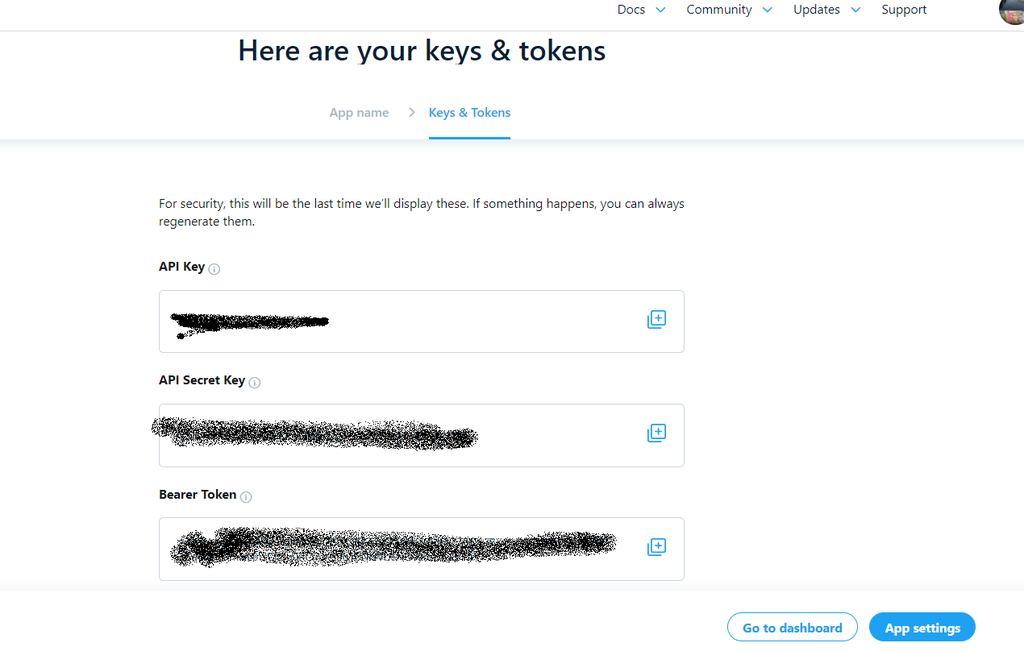

## Cuando tengamos configurada la app, tendremos que también generar **“Access token and Secret”**.

[figure not shown]

Los copiamos y los dejamos a mano, y ¡a codificar!. Recuerden **no compartir keys y tokens de su app** cuando comparten código.